# Test a Perceptual Phenomenon

### Analyzing the Stroop Effect

Perform the analysis in the space below. Remember to follow [the instructions](https://docs.google.com/document/d/1-OkpZLjG_kX9J6LIQ5IltsqMzVWjh36QpnP2RYpVdPU/pub?embedded=True) and review the [project rubric](https://review.udacity.com/#!/rubrics/71/view) before submitting. Once you've completed the analysis and write-up, download this file as a PDF or HTML file, upload that PDF/HTML into the workspace here (click on the orange Jupyter icon in the upper left then Upload), then use the Submit Project button at the bottom of this page. This will create a zip file containing both this .ipynb doc and the PDF/HTML doc that will be submitted for your project.

(1) What is the independent variable? What is the dependent variable?

The inependent variable is the person who is doing the task and dependent variable is the time

(2) What is an appropriate set of hypotheses for this task? Specify your null and alternative hypotheses, and clearly define any notation used. Justify your choices.

Null : Ho : Average time consumed to read incongruent words is the same or less to congruent words.

Alternative : H1 : Average time consumed to read incongruent words is more than that consumed to read congruent words.

**The reasnons for setting these hypotheses :**

The two hypotheses must be competing and non overlapping. The null hypothesis contains the equal sign as usual.

(3) Report some descriptive statistics regarding this dataset. Include at least one measure of central tendency and at least one measure of variability. The name of the data file is 'stroopdata.csv'.

```python
# calling libraries
import pandas as pd
import numpy as np
import matplotlib.pyplot as plt
%matplotlib inline

df = pd.read_csv("stroopdata.csv")
# have a brief look
df.head(3)
```

|  | Congruent | Incongruent |
| --- | --- | --- |
| 0 | 12.079 | 19.278 |
| 1 | 16.791 | 18.741 |
| 2 | 9.564 | 21.214 |

```python
# Measure of center :
df.describe()
```

|  | Congruent | Incongruent |
| --- | --- | --- |
| count | 24.000000 | 24.000000 |
| mean | 14.051125 | 22.015917 |
| std | 3.559358 | 4.797057 |
| min | 8.630000 | 15.687000 |
| 25% | 11.895250 | 18.716750 |
| 50% | 14.356500 | 21.017500 |
| 75% | 16.200750 | 24.051500 |
| max | 22.328000 | 35.255000 |

It is obvious that from the above results that the average time for congruent is about 14 sec and for incongruent is 22 seconds. This is against the null hypothesis but the p-value must be calculated to have the proof to reject the null hypothesis.

The variability of the two datasets is not too much. It is only about 3.55 for congruent and 4.79 for incongruent. This means taht people in our test are not totally different and their abilities to concentrate is are alomst equal.

(4) Provide one or two visualizations that show the distribution of the sample data. Write one or two sentences noting what you observe about the plot or plots.

```
array([[<matplotlib.axes._subplots.AxesSubplot object at 0x7f3b978a0710>,
        <matplotlib.axes._subplots.AxesSubplot object at 0x7f3b9776ca20>]], dtype=object)
```

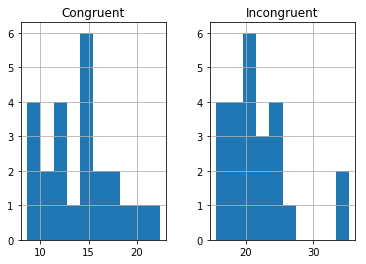

```python
# Build the visualizations here
df.hist()
```

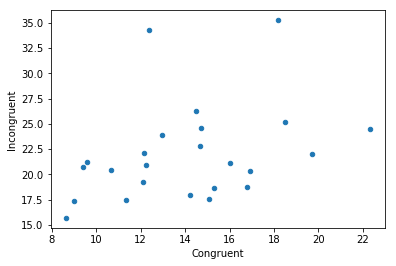

```python
df.plot(x='Congruent',y='Incongruent',kind='scatter')
```

Because the dataset consists only from 24 rows , the scatter plot is very obvious and it can tell us that most of the dataset had nearly the same perfromance because the dots were concentrated in the middle area of the graph

(5) Now, perform the statistical test and report your results. What is your confidence level or Type I error associated with your test? What is your conclusion regarding the hypotheses you set up? Did the results match up with your expectations? **Hint:** Think about what is being measured on each individual, and what statistic best captures how an individual reacts in each environment.

```python
# Perform the statistical test here
# the observed mean
obs_mean_diff = df['Incongruent'].mean() - df['Congruent'].mean()
# bootstrap sampling
means=[]
for i in range(10000):
    boot_sample= df.sample(24,replace= True)

    time_con = boot_sample['Congruent'].mean()
    time_incon = boot_sample['Incongruent'].mean()
    means.append(time_incon - time_con)                # array holding all means of all samples
```

```python
obs_mean_diff
```

```
7.9647916666666667
```

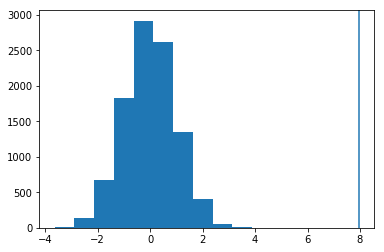

```python
# generating the null values that follw the null hypothesis and making a histogram
null_vals=np.random.normal(0,np.std(means),10000)
# plotting a hist for the null values
plt.hist(null_vals)
#plotting the oserved value on the histogram to calculate the p-value
plt.axvline(x= obs_mean_diff)
```

(6) Optional: What do you think is responsible for the effects observed? Can you think of an alternative or similar task that would result in a similar effect? Some research about the problem will be helpful for thinking about these two questions!

I think the responsible for this effect is that our brains can translate direct speech but thet need more time to identify colors and take the decision to prononcue the color not the word itself. ِAnother task is to show people a square and inside it we write a circle or a triangle and then the people are asked to say the name of the shape not the word in it.

I have used this link for more information about the stroop effect. https://www.youtube.com/watch?v=EGpzftQf8oI&t=86s I did not use any other resources and I just depended on the Udacity introduction about the strrop effect and the project